# Pershing Square Hedging Analysis

This section provides a comprehensive quantitative analysis of Pershing Square's hedging strategies, conducted through a series of Jupyter notebooks. It evaluates the fund's various hedging options, which were previously discussed in the context of the report. Key areas of analysis include the examination of contract size, positioning, maturities, market timing, cashflows, and associated costs, as well as expected outcomes and payoffs as specified in the task brief. The analysis also incorporates sensitivity tests for different market scenarios in relation to the chosen hedging contracts. Additionally, a literature review explores the mechanics of each hedging option, with relevant coding examples provided. Assumptions for each hedging strategy are clearly outlined throughout the analysis.

### Scope of the Research:

1. **No Hedging**: An analysis of the risks and rewards of not engaging in any hedging activities.
2. **Partial or Full Portfolio Liquidation into Cash**: The implications of converting assets into cash as a risk mitigation strategy.
3. **S&P 500 Index Futures**: The potential of futures contracts on the S&P 500 index as a hedging tool.
4. **S&P 500 Index Options**: An exploration of the strategic use of options contracts on the S&P 500 index.
5. **Index Credit Default Swaps (CDS)**: A detailed evaluation of using CDS contracts to hedge against market downturns.

Each of these options is evaluated not only for its immediate financial impact but also through the lens of potential future market scenarios.

### Main Assumptions and Limitations maintained over Hedging concepts:

**1. Share Price**  
One observed limitation includes discrepancies between the share price of Pershing Square's portfolio and the price listed on Yahoo Finance. For example, the share price of Chipotle Mexican Grill (Ticker: CMG) was derived by dividing the value of their stake by the number of shares in the portfolio:

**2. Evaluation Date**  
For the purposes of this assignment, we will assume that the evaluation date (i.e. the date in which Pershing Square must make a decision on their Hedging strategy) is February 21, 2020.

**3. Hedging amount**

- Sections **1** and **2**, only the notional value of the portfolio was considered.
- Sections **3** and **4** utilised optimal hedging techniques to determine the number of contracts to hedge.
- Section **5** used the notional value of Pershing Square's portfolio to hedge with CDS. Further analysis was performed on the CDS positions Pershing Square wrote later in the report.

# 1. No Hedging

The analysis of the no-hedging strategy disregards several key considerations, such as contract size, number of contracts, position, and ongoing cashflows since no hedging instruments are employed. Instead, the focus is on the valuation of Pershing Square’s portfolio over a six-month (180-day) period and the projected value of their holdings.

**Table of Contents**

- 1.1 Unhedged Portfolio Value
- 1.2 Acknowledgements and Tooling

**Tooling**

```python
pip install yfinance openpyxl pandas matplotlib
```

**Libraries**

```python
import yfinance as yf
import pandas as pd
from datetime import datetime, timedelta
import matplotlib.pyplot as plt
import matplotlib.dates as mdates
```

***Exhibit 3* data**

```python
file_path = 'Perishing_portfolio.xlsx'
sheet_name = 'portfolio'
evaluation_date = '2020-02-21'
days = 180
evaluation_date_next = datetime.strptime(evaluation_date, '%Y-%m-%d') + timedelta(days=days)

df = pd.read_excel(file_path, sheet_name=sheet_name)
df.head(9)
```

|  | Firm Name | Ticker Code | Number of Shares | Value (in $ million) | Share price | % Ownership | % of Fund Value | Board Seat | Inception Date |
| --- | --- | --- | --- | --- | --- | --- | --- | --- | --- |
| 0 | Chipotle Mexican Grill | CMG | 8.619146e+07 | 1494.56 | 17.340000 | 0.0620 | 0.213 | Yes | 2016-08-01 |
| 1 | Hilton Worldwide | HLT | 1.055680e+07 | 1138.02 | 107.799661 | 0.0374 | 0.162 | No | 2018-10-01 |
| 2 | Lowe's Companies | LOW | 8.613212e+06 | 1001.20 | 116.240028 | 0.0112 | 0.143 | No | 2018-04-01 |
| 3 | Restaurant Brands International | QSR | 1.546818e+07 | 943.71 | 61.009759 | 0.0334 | 0.134 | No | 2012-06-01 |
| 4 | Berkshire Hathaway (B) | BRK-B | 4.015594e+06 | 901.22 | 224.430059 | 0.0029 | 0.128 | No | 2019-05-01 |
| 5 | Howard Hughes | HHH | 6.386835e+06 | 777.15 | 121.679987 | 0.1478 | 0.111 | Yes | 2010-11-01 |
| 6 | Agilent Technologies | A | 8.807760e+06 | 727.17 | 82.560152 | 0.0284 | 0.104 | No | 2019-09-01 |
| 7 | Fannie Mae | FNMA | 1.310045e+08 | 417.90 | 3.189966 | 0.1131 | 0.060 | No | 2013-10-01 |
| 8 | Freddie Mac | FMCC | 7.201052e+07 | 220.35 | 3.059969 | 0.1108 | 0.031 | No | 2013-10-01 |

## 1.1 Unhedged Portfolio Value

```python
share_nums = {}

for index, row in df.iterrows():
    ticker = row['Ticker Code']
    shares = row['Number of Shares']
    share_nums[ticker] = shares


date_range = pd.date_range(start=evaluation_date, end=evaluation_date_next)
portfolio_values = pd.DataFrame(index=date_range)

# Stock prices for the evaluation period
for ticker, shares in share_nums.items():
    historical_data = yf.download(ticker, start=evaluation_date, end=evaluation_date_next)["Adj Close"]

    if not historical_data.empty:
        daily_values = historical_data * shares
        portfolio_values[ticker] = daily_values

portfolio_values.fillna(method='ffill', inplace=True)
portfolio_values['Firm Value'] = portfolio_values.sum(axis=1)

print(f"\nTotal portfolio value on {evaluation_date}: ${portfolio_values['Firm Value'].loc[evaluation_date]:.2f}")

# Safekeeping:
portfolio_values.index.name = 'Date'
portfolio_values.to_excel('portfolio_value.xlsx', sheet_name='Portfolio Values')

portfolio_values.head()
```

[output not shown]

```
Total portfolio value on 2020-02-21: $7697405984.92
```

| Date | CMG | HLT | LOW | QSR | BRK-B | HHH | A | FNMA | FMCC | Firm Value |
| --- | --- | --- | --- | --- | --- | --- | --- | --- | --- | --- |
| 2020-02-21 | 1.586164e+09 | 1.143925e+09 | 9.953334e+08 | 8.627389e+08 | 9.208962e+08 | 7.823721e+08 | 7.265872e+08 | 4.532756e+08 | 2.261130e+08 | 7.697406e+09 |
| 2020-02-22 | 1.586164e+09 | 1.143925e+09 | 9.953334e+08 | 8.627389e+08 | 9.208962e+08 | 7.823721e+08 | 7.265872e+08 | 4.532756e+08 | 2.261130e+08 | 7.697406e+09 |
| 2020-02-23 | 1.586164e+09 | 1.143925e+09 | 9.953334e+08 | 8.627389e+08 | 9.208962e+08 | 7.823721e+08 | 7.265872e+08 | 4.532756e+08 | 2.261130e+08 | 7.697406e+09 |
| 2020-02-24 | 1.525589e+09 | 1.085983e+09 | 9.762703e+08 | 8.423065e+08 | 8.902170e+08 | 7.665420e+08 | 6.875547e+08 | 4.362450e+08 | 2.196321e+08 | 7.430339e+09 |
| 2020-02-25 | 1.475615e+09 | 1.032320e+09 | 9.414006e+08 | 8.243628e+08 | 8.756003e+08 | 7.295239e+08 | 6.657751e+08 | 3.969437e+08 | 2.052300e+08 | 7.146772e+09 |

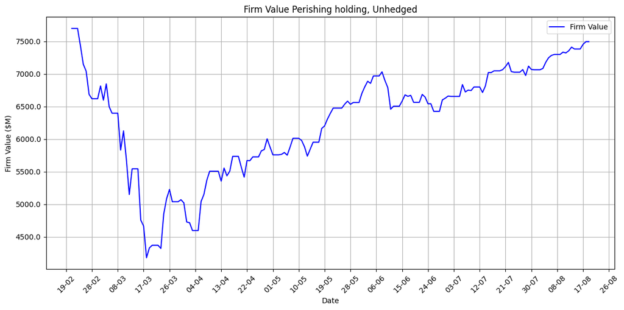

```python
import matplotlib.ticker as ticker
plot_x_axis_interval = days / 20

plt.figure(figsize=(12, 6))
plt.plot(portfolio_values.index, portfolio_values['Firm Value'], linestyle='-', color='b', label='Firm Value')
plt.title('Firm Value Perishing holding, Unhedged')
plt.xlabel('Date')
plt.ylabel('Firm Value ($M)')
plt.xticks(rotation=45)
plt.gca().xaxis.set_major_locator(mdates.DayLocator(interval=int(plot_x_axis_interval)))
plt.gca().xaxis.set_major_formatter(mdates.DateFormatter('%d-%m'))  # format it
plt.gca().yaxis.set_major_formatter(ticker.FuncFormatter(lambda x, pos: f'{x*1e-6:.1f}'))
plt.grid()
plt.legend()
plt.tight_layout()
plt.show()
```

### 1.2 Acknowledgements and Tooling

This work is licensed under the MIT License and is freely available for distribution. All rights are reserved by the author, DanielCiccC.

- Various tools, including GitHub, GitHub Copilot, and ChatGPT, were utilised in the development and analysis of this project.
- Portions of the code were adapted from examples provided in lectures.

[output not shown]